# Time Series Assignment 4

Gavin Connolly

23/11/2021

## Exercise 1

#### You observe a time series {x} = (−1, 6, 1, 20, 28, 14, 30, 21, 18, 20)

#### (a) Fit an AR(1) model with drift and report the estimates for the coefficients in your model.

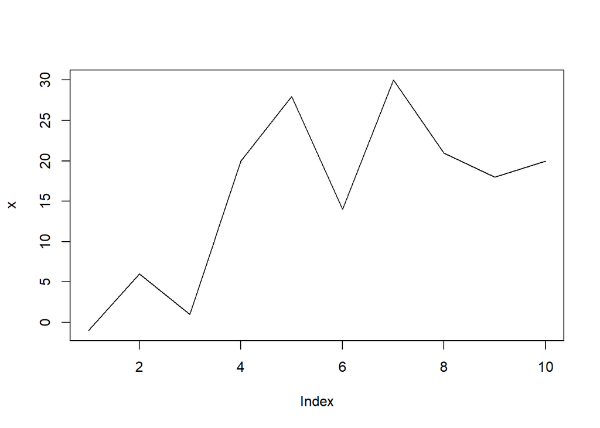

```r
x = c(-1, 6, 1, 20, 28, 14, 30, 21, 18, 20)
plot(x, type = 'l')
```

```r
modelx = Arima(x, order = c(1, 0, 0), include.drift = T)
coeftest(modelx)
```

```
##
## z test of coefficients:
##
##           Estimate Std. Error z value Pr(>|z|)
## ar1        0.04413    0.32649  0.1352 0.892479
## intercept  2.68023    5.29368  0.5063 0.612641
## drift      2.35692    0.84895  2.7763 0.005499 **
## ---
## Signif. codes:  0 '***' 0.001 '**' 0.01 '*' 0.05 '.' 0.1 ' ' 1
```

Model reports coefficients of:

- 0.044 for the autoregressive term $\phi_1$
- 2.68 for the intercept term
- 2.357 for the drift term $\mu$

Only the drift term is significant in this case.

#### (b) What are the minimum mean squared error forecasts for the next 10 timepoints?

```r
forecast(modelx, h = 10)$mean
```

```
## Time Series:
## Start = 11
## End = 20
## Frequency = 1
##  [1] 28.33053 30.95107 33.31962 35.67705 38.03399 40.39091 42.74782 45.10474
##  [9] 47.46166 49.81858
```

```r
# Model includes a drift component, meaning the model will tend toward infinity as expectation of the random component = 0
```

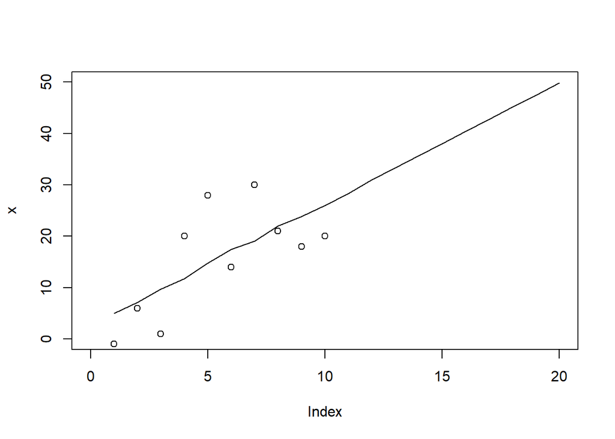

```r
plot(x, xlim = c(0,20), ylim = c(0,50))
lines(union(fitted(modelx), forecast(modelx, h = 10)$mean))
```

#### (c) Comment on these forecasts. What are they moving towards and why?

Forecasts moving towards infinity as there is a positive drift term present in the time series model meaning that as the model is unbounded and increasing linearly with time, the forecast tends to infinity as the number of time points tends to infinity.

## Exercise 2

#### Look at the prescrip time series dataset in the TSA package by running library(TSA) and data(prescrip). This is monthly U.S. average prescription costs for 68 months from August 1986.

```r
data(prescrip)
prescrip
```

```
##          Jan     Feb     Mar     Apr     May     Jun     Jul     Aug     Sep
## 1986                                                         14.5471 14.6721
## 1987 14.3250 14.6231 15.1362 15.2200 15.7592 16.0724 16.1126 16.1826 16.4537
## 1988 16.5005 16.8483 16.5935 17.4391 17.9894 17.8031 18.5141 18.8180 19.2117
## 1989 18.9739 18.5933 19.3313 20.1503 20.9867 21.1868 21.8878 21.8578 22.4741
## 1990 21.8922 22.2364 23.0349 23.4658 24.6513 24.7339 25.2870 25.3264 25.7877
## 1991 24.5715 24.2925 25.4905 26.1685 27.0857 27.4766 28.2164 27.9908 28.1535
## 1992 27.9715 29.4773 30.6624
##          Oct     Nov     Dec
## 1986 14.8016 14.6125 14.2967
## 1987 15.9885 16.1646 16.6733
## 1988 18.9650 18.7972 19.1667
## 1989 22.1601 21.9503 21.9989
## 1990 25.1988 25.4100 25.2900
## 1991 27.5391 27.9092 26.8256
## 1992
```

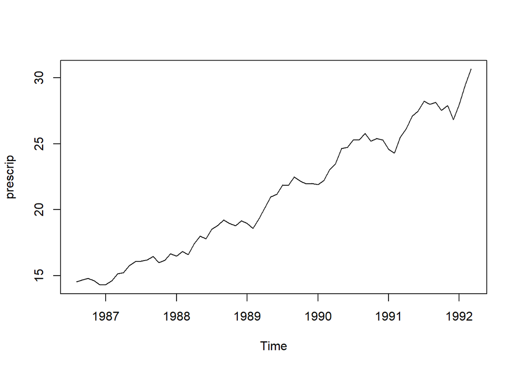

```r
plot(prescrip)
```

#### (a) Use the Augmented Dickey-Fuller test to test for whether the time series has a unit root, assuming a significance level of 0.05 and setting the lag order to be k = 0 so that the alternative hypothesis is a model with a linear trend and one autoregressive coefficient. What do you conclude and why?

```r
adf.test(prescrip, k = 0)
```

```
##
##  Augmented Dickey-Fuller Test
##
## data:  prescrip
## Dickey-Fuller = -2.7968, Lag order = 0, p-value = 0.2515
## alternative hypothesis: stationary
```

```r
# fail to reject null hypothesis of unit root
```

Augmented Dickey-Fuller Test returns test statistic of -2.8, which has a corresponding p-value of 0.25. As this is does not fall below the critical value of 0.05 for this test, we fail to reject the null hypothesis that the time series has a unit root. We therefore conclude that the time series is integrated, as there is not sufficient evidence to reject our null hypothesis.

#### (b)

We’d also like to find the $\Phi_2$ test statistic for the test whether ($\alpha$, $\beta$, $\phi$) = (0, 0, 1) in the model given by:

$X_t = \alpha + \beta t + \phi X_{t−1} + \epsilon_t.$ where $X_t$ is the average prescription cost in month t. This model can be re-written as:

$\Delta X_t = \alpha + \beta t + \omega X_{t−1} + \epsilon_t$. (where $\omega = \phi−1$). To do this you first fit a linear model to the time series to estimate the coefficients:

```
  n=length(prescrip)

  tt=2:n # convenience vector of time indices

  y=diff(prescrip) # first difference of the series

  fit=lm(y˜tt+prescrip[-n]) # estimate alpha, omega x[t-1], beta

  yhat=fitted(fit)
```

Once this is done, $\Phi_2$ (equivalent to an F statistic) will be given by the ratio of explained to unexplained variance. This in turn is equal to the ratio of the sum of squares of the model divided by the degrees of freedom of the model to the sum of squares of the errors divided by the degrees of freedom of the errors:

$\Phi_2 = \frac{SSM/dof_m}{SSE/dof_e}$.

where,
$$SSM = \sum^{n}_{t=1} \hat{y}_t^2$$
$$SSE = \sum^{n}_{t=1} (y-\hat{y}_t)^2$$
you can for example use SSE=sum((y-yhat)ˆ2) for the sum or squared errors and the degrees of freedom are p for the model and n − p − 1 for the errors, where p = 3 is the number of parameters.

```r
n = length(prescrip)
tt = 2:n
y= diff(prescrip)
fit = lm(y~tt+prescrip[-n])
yhat = fitted(fit)

SSM = sum(yhat^2)
SSE = sum((y-yhat)^2)
dofM = 3
dofE = n-4 # length of y = n, so dofE = n-1-3 = n-4
phi2 = (SSM/dofM)/(SSE/dofE)
phi2 # phi2 = 8.8117
```

```
## [1] 8.811688
```

Filling in the values for the sum of square of the model, the sum of squares of the errors, the degrees of freedom of the model & the degrees of freedom of the errors, we get $\Phi_2 = 8.8117$

#### (c) Load the urca package and verify this test statistic. You can find it by using the ur.df function with arguments type=‘trend’ and lags=0 and then calling summary() on the result. You are looking for the F-statistic: What is the difference between this test and the test of part (a)?

```r
test = ur.df(prescrip, type = 'trend', lags = 0)
summary(test)
```

```
##
## ###############################################
## # Augmented Dickey-Fuller Test Unit Root Test #
## ###############################################
##
## Test regression trend
##
##
## Call:
## lm(formula = z.diff ~ z.lag.1 + 1 + tt)
##
## Residuals:
##      Min       1Q   Median       3Q      Max
## -1.44289 -0.33147  0.01302  0.33358  1.04300
##
## Coefficients:
##             Estimate Std. Error t value Pr(>|t|)
## (Intercept)  3.17952    1.10825   2.869  0.00557 **
## z.lag.1     -0.23663    0.08461  -2.797  0.00681 **
## tt           0.05913    0.01987   2.975  0.00413 **
## ---
## Signif. codes:  0 '***' 0.001 '**' 0.01 '*' 0.05 '.' 0.1 ' ' 1
##
## Residual standard error: 0.4816 on 64 degrees of freedom
## Multiple R-squared:  0.1319, Adjusted R-squared:  0.1048
## F-statistic: 4.862 on 2 and 64 DF,  p-value: 0.01082
##
##
## Value of test-statistic is: -2.7968 8.8117 4.862
##
## Critical values for test statistics:
##       1pct  5pct 10pct
## tau3 -4.04 -3.45 -3.15
## phi2  6.50  4.88  4.16
## phi3  8.73  6.49  5.47
```

From the summary of the ur.df test output we see that the $\Phi_2$–statistic for the test is also equal to 8.8117.

## Exercise 3

#### Load the beersales dataset in the TSA package by running data(beersales). You will model monthly beersales in millions of barrels and perform the following tasks.

#### (a) Create plots using tsdisplay() and comment on them. Also perform an Augmented Dickey- Fuller test for unit roots and comment on the result.

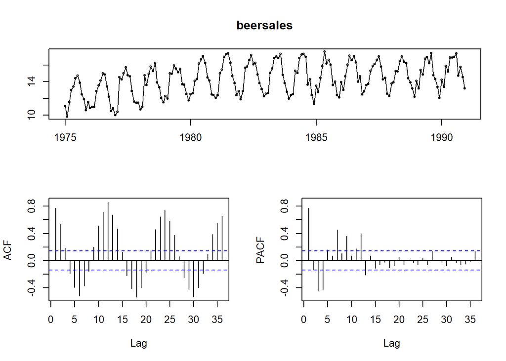

```r
data(beersales)
tsdisplay(beersales)
```

From the ACF plot we can clearly see that there is a seasonal component with a period of 12 lags in the data. The magnitude of the seasonal component does not appear to evolve with time, suggesting an additive decomposition for the seasonal component, rather than a multiplicative one.

From the plot of the time series itself we can also see that there appears to be an increasing trend component to the data, with this trend component seeming to level off for later time points.

```r
adf.test(beersales)
```

```
##
##  Augmented Dickey-Fuller Test
##
## data:  beersales
## Dickey-Fuller = -9.7734, Lag order = 5, p-value = 0.01
## alternative hypothesis: stationary
```

```r
# ADF test reports p-value < 0.01, so we reject null hypothesis and conclude there is no unit root & that series is stationary.
```

The ADF test reports a p-value which is less than 0.01, meaning we reject the null hypothesis that there is a unit root to the time series at a 1% level of significance, and accept the alternative hypothesis that no unit root exists and therefore the series is stationary with a trend component.

#### (b) Estimate a trend by smoothing the series and plot it. What order do you choose for the moving average smoother and why?

```r
TC = ma(beersales, 12) # chose order 12 for MA smoother as peaks/troughs of ACF separated by 12 time lags
```

We choose a 12-MA smoother as the period of the seasonal component is 12 time points (peaks/troughs in the ACF plot of the series separated by 12 time lags).

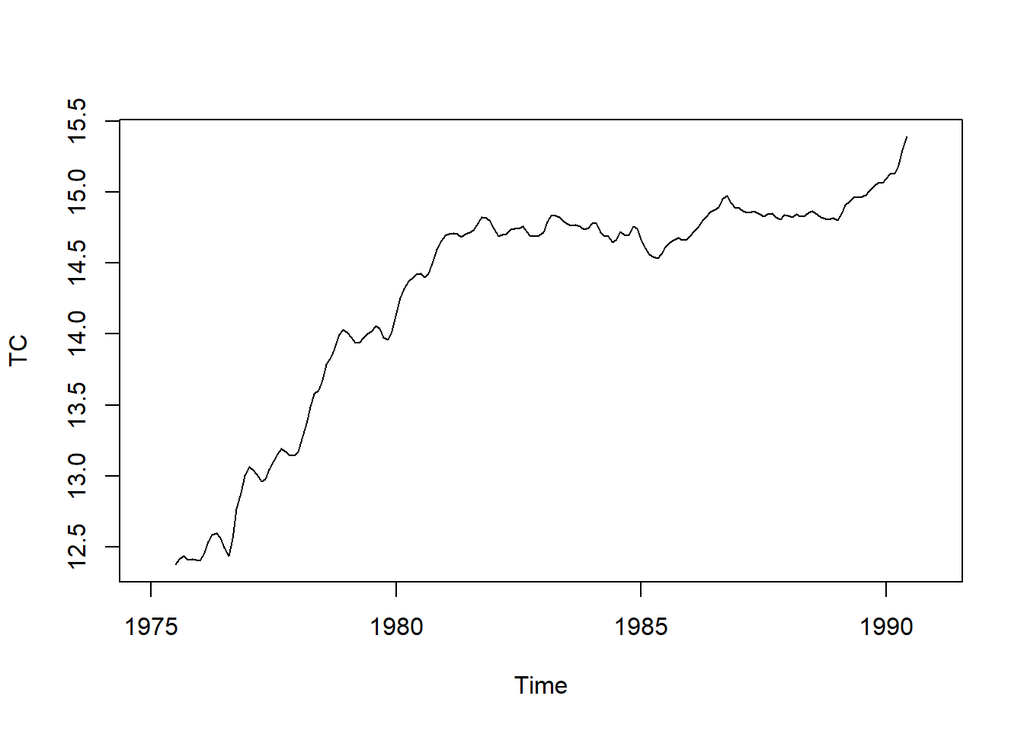

```r
plot(TC)
```

#### (c) Hence decompose the time series as an additive model with trend, seasonal, and random components. Find the seasonal and random components and plot them against time. Centre the seasonal component on zero.

```r
pseudo_S = beersales-TC
matrix_S = matrix(pseudo_S, nrow = 12)
s = rowMeans(matrix_S, na.rm = TRUE)
S = s-mean(s) # Centre seasonal component
R = beersales - TC - S # Calculate random component
```

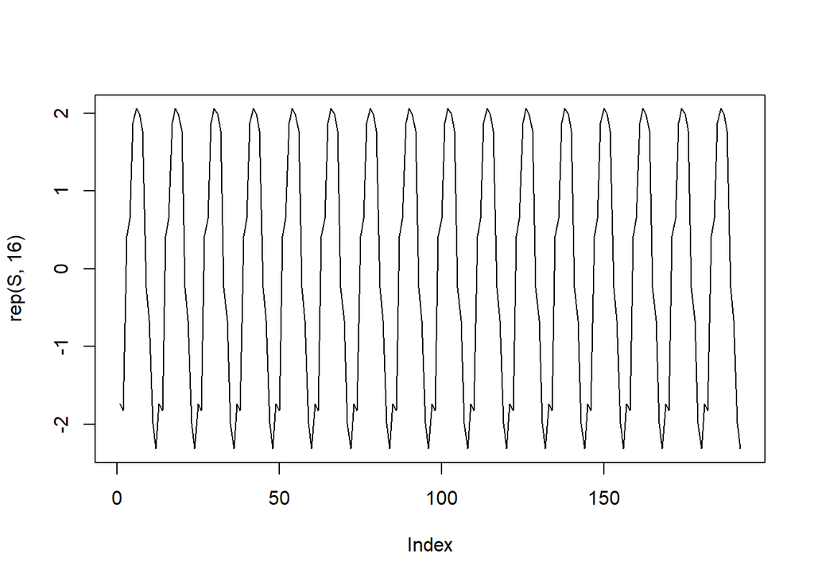

```r
plot(rep(S, 16), type = 'l')
```

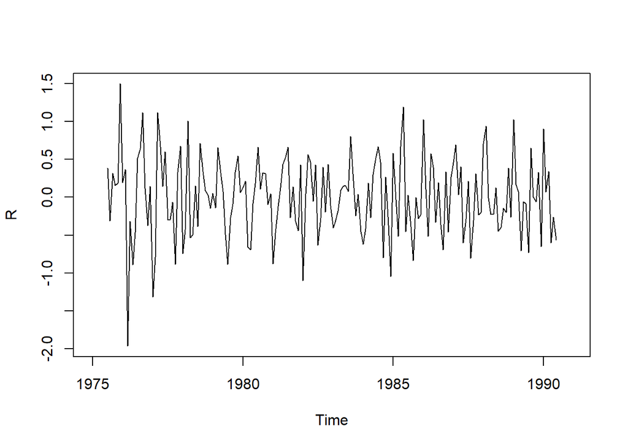

```r
plot(R)
```

#### (d) Fit a linear trend by fitting a linear model using linear tc=lm(TC˜time(beersales)). Then create the deterministic part of a forecast by adding the trend and seasonal components extrapolated forward 2 years. Hint: You should use deltat(beersales) to get the time gap between time points.

```r
linear_TC = lm(TC~time(beersales))
t = deltat(beersales)
newdata = seq(1991, 1993-t, t)
pred_TC = linear_TC$coefficients[2]*newdata + linear_TC$coefficients[1]
pred_beersales = pred_TC + rep(S, 2)
pred_beersales
```

```
##  [1] 13.83226 13.76234 16.01710 16.25389 17.49953 17.69644 17.64251 17.43984
##  [9] 15.43609 15.02343 13.71341 13.39790 13.98940 13.91948 16.17424 16.41103
## [17] 17.65667 17.85358 17.79964 17.59697 15.59323 15.18056 13.87055 13.55503
```

#### (e) Use the above to calculate the minimum means-squared error forecast for the next 2 years and plot the mean of this forecast.

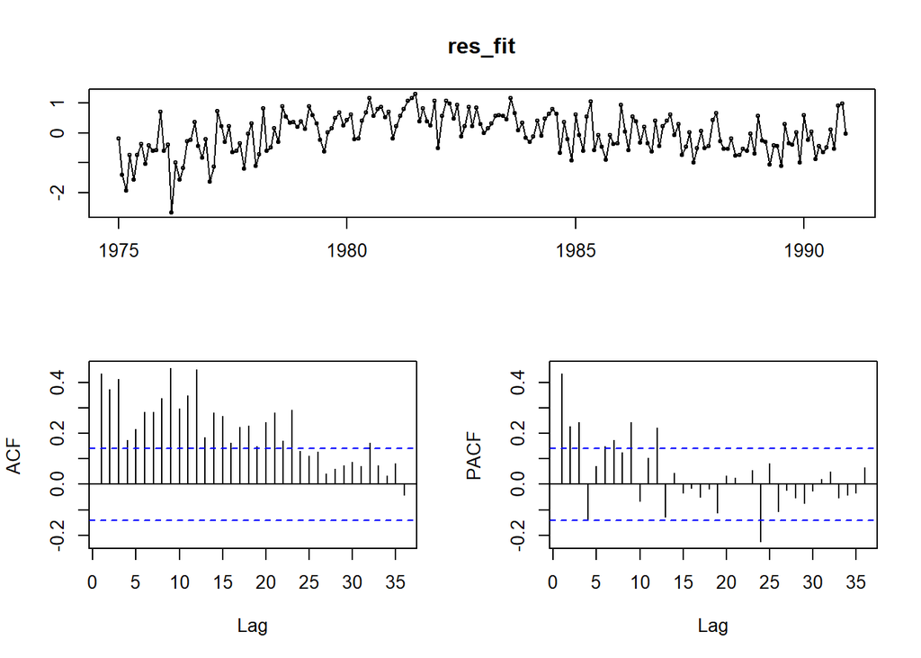

```r
LinTC = linear_TC$coefficients[2]*time(beersales) + linear_TC$coefficients[1]
fit_beersales = LinTC + rep(S, 16)
res_fit = beersales - fit_beersales
tsdisplay(res_fit) # ACF & PACF plots of residuals both tail off indicating an ARMA process
```

```r
model_res = Arima(res_fit, order = c(1, 0, 1), include.mean = F)
coeftest(model_res)
```

```
##
## z test of coefficients:
##
##      Estimate Std. Error z value  Pr(>|z|)
## ar1  0.983599   0.016378  60.055 < 2.2e-16 ***
## ma1 -0.848153   0.043449 -19.521 < 2.2e-16 ***
## ---
## Signif. codes:  0 '***' 0.001 '**' 0.01 '*' 0.05 '.' 0.1 ' ' 1
```

```r
f_res = forecast(model_res, h = 30)

msef = pred_beersales + f_res$mean[-c(1:6)]
msef
```

```
##  [1] 13.83824 13.76823 16.02289 16.25958 17.50513 17.70195 17.64793 17.44517
##  [9] 15.44133 15.02858 13.71849 13.40289 13.99430 13.92431 16.17898 16.41570
## [17] 17.66126 17.85810 17.80409 17.60135 15.59753 15.18479 13.87471 13.55913
```

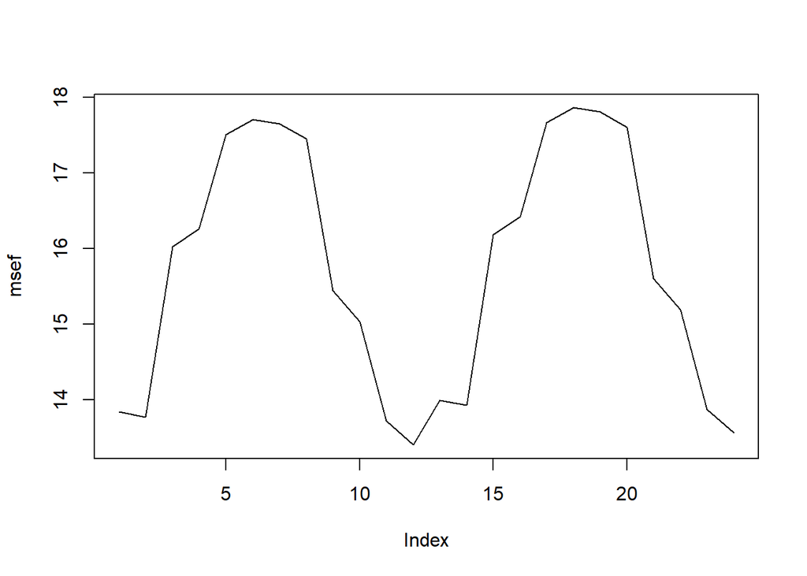

```r
plot(msef, type = 'l')
```

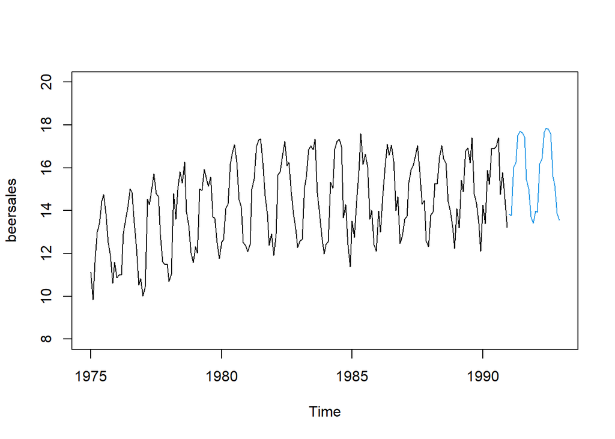

```r
plot(beersales, xlim=c(time(beersales)[1], newdata[length(newdata)]), ylim=c(8, 20))
lines(newdata, msef, col=4)
```